# PEC 2 Anàlisis de Dades Òmiques

Sheddad Kaid-Salah Ferrón

2023-12-21

# 1 Introducció i Objectius

Amb aquesta activitat es pretén fer una introducció de forma pràctica a l’ús de R per a la gestió de dades de microarrays.  
Força dades òmiques, un cop processades, es poden emmagatzemar com a dades numèriques que es poden representar com “matriu de dades” en la que els gens (variables) estan en files i les mostres (individus) estan en columnes.  
Tot i això, el conjunt d’aquestes dades òmiques tenen més informació que la que es pot emmagatzemar en una taula com ara dades d’anotacions, diverses covariables o informació sobre l’experiment.

La classe **ExpressionSet** del paquet [Bioconductor](https://www.bioconductor.org/) de R, permet emmagatzemar i accedir a dades de microarrays de manera que podem gestionar simultàniament totes aquestes peces d’informació; és a dir, ens ajuda a simplificar el procés i evitar errors derivats de la falta de coherència entre les parts.

Les dades per aquesta pràctica les hem obtingut de la base de dades [GEO](https://www.ncbi.nlm.nih.gov/geo/) ( Gene Expression Omnibus), un repositori públic per a una àmplia gamma de dades experimentals que inclouen experiments basats en microarrays que mesuren l’ARNm, l’ADN genòmic i l’abundància de proteïnes, així com tècniques sense matriu com l’anàlisi en sèrie de l’expressió gènica (SAGE), dades proteòmiques d’espectrometria de masses i dades de seqüenciació d’alt rendiment.

L’estudi que hem escollit és GDS1251, «A physiogenomic approach to study the regulation of blood pressure» que tal i com expliquen els propis autors «l’objectiu de aquests estudi és establir un model de cribratge fisiogenòmic per a gens expressats de manera diferencial en la regulació de la pressió arterial que pogui donar una pista sobre nous mecanismes vasoreguladors.»

Amb les dades d’aquest estudi farem una anàlisi bàsica de dades de microarrays per donar resposta al problema biològic que plantegen els autors.

Finalment, presentarem en aquest informe els resultats obtinguts i valorarem la qualitat de les dades així com les diferents tècniques emprades.

Es pot accedir al [repositori](https://github.com/Sheddad/MasterBioInf-ADO-PEC2_GeneAnalisys.git) de la pràctica.

# 2 Mètodes

En l’estudi es va induir hipotensió aguda en 4 rates normotenses, suposant que els sistemes vasoreguladors contrarestaran la hipotensió. L’anàlisi del transcriptoma de microarrays es va realitzar a partir dels ronyons 6 hores després de la inducció de la hipotensió aguda. Els resultats es van confirmar mitjançant PCR en temps real. Es van fer servir 5 rates com a control.

## 2.1 Preparació del sistema: directoris i paquets

Oraganitzem el projecte fent servir directoris per ordenar les dades i els resultats.

```r
workingDir <- getwd()
dataDir <- file.path(workingDir, "data")
resultsDir <- file.path(workingDir, "results")
```

Instalem els paquets requerits en cas que no ho estiguin. Per tal que no ho faci cada vegada farme servir la funció **installifnot**.

```r
# De moment no l'executem perquè no ens ho faci cada vegada
if (!require(BiocManager)) install.packages("BiocManager")

installifnot <- function(pkg) {
    if (!require(pkg, character.only = T)) {
        BiocManager::install(pkg)
    }
}
# BiocManager::install() # Actualitza paquets instal·lats
installifnot("rae230a.db")
installifnot("mogene10sttranscriptcluster.db")
installifnot("oligo")
installifnot("limma")
installifnot("Biobase")
installifnot("arrayQualityMetrics")
installifnot("genefilter")
installifnot("annotate")
installifnot("xtable")
installifnot("gplots")
installifnot("GOstats")
installifnot("GEOquery")
installifnot("clusterProfiler")
installifnot("kableExtra")
```

## 2.2 Lectura de les dades

### 2.2.1 Dades crues (Raw Data)

Les mostres estan agrupades en dos grups, les rates a què se’ls ha induït una hipotensió aguda (Hypotension) i als qui no (Control). Emmagatzemem aquesta informació al fitxer *targets.csv*.

```r
require(Biobase)
# Llegim l'arxiu targets.csv en un dataframe
targetsDF <- read.csv(file = file.path(dataDir, "targets.csv"), header = TRUE, sep = ",")
# Visualitzem l'arxiu targets
targetsDF
```

```
      fileName     groups ShortName Colors
1 GSM45184.CEL    Control   84_Norm   blue
2 GSM45186.CEL    Control   86_Norm   blue
3 GSM45187.CEL    Control   87_Norm   blue
4 GSM45189.CEL    Control   89_Norm   blue
5 GSM45193.CEL    Control   93_Norm   blue
6 GSM45188.CEL Hypotesion   88_Hypo    red
7 GSM45190.CEL Hypotesion   90_Hypo    red
8 GSM45191.CEL Hypotesion   91_Hypo    red
9 GSM45192.CEL Hypotesion   92_Hypo    red
```

```r
# Definim variables pels gràfics
sampleNames <- as.character(targetsDF$ShortName)
sampleColor <- as.character(targetsDF$Colors)
# Creem un objecte AnnotatedDataFrame
targets <- AnnotatedDataFrame(targetsDF)
```

Extraurem les dades del arxius .CEL que ens hem descarregat i hem guardat al fitxer *dades*.

Llegim els arxius .CEL fent servir la informació continguda en el data frame *targets*.  
Guardarem les dades en l’objecte *rawData* que és del tipus *ExpressionFeatureSet*, un tipus especial *d’ExpressionSet*.

```r
# Fitxers .CEL amb la info que hem tret de l'arxiu 'target.csv'
CELfiles <- targetsDF$fileName
rawData <- read.celfiles(file.path(dataDir, CELfiles), phenoData = targets)
```

```
Reading in : /home/sheddad/Escriptori/PEC_2_ADO/MasterBioInf-ADO-PEC2_GeneAnalisys/data/GSM45184.CEL
Reading in : /home/sheddad/Escriptori/PEC_2_ADO/MasterBioInf-ADO-PEC2_GeneAnalisys/data/GSM45186.CEL
Reading in : /home/sheddad/Escriptori/PEC_2_ADO/MasterBioInf-ADO-PEC2_GeneAnalisys/data/GSM45187.CEL
Reading in : /home/sheddad/Escriptori/PEC_2_ADO/MasterBioInf-ADO-PEC2_GeneAnalisys/data/GSM45189.CEL
Reading in : /home/sheddad/Escriptori/PEC_2_ADO/MasterBioInf-ADO-PEC2_GeneAnalisys/data/GSM45193.CEL
Reading in : /home/sheddad/Escriptori/PEC_2_ADO/MasterBioInf-ADO-PEC2_GeneAnalisys/data/GSM45188.CEL
Reading in : /home/sheddad/Escriptori/PEC_2_ADO/MasterBioInf-ADO-PEC2_GeneAnalisys/data/GSM45190.CEL
Reading in : /home/sheddad/Escriptori/PEC_2_ADO/MasterBioInf-ADO-PEC2_GeneAnalisys/data/GSM45191.CEL
Reading in : /home/sheddad/Escriptori/PEC_2_ADO/MasterBioInf-ADO-PEC2_GeneAnalisys/data/GSM45192.CEL
```

```r
rawData
```

```
ExpressionFeatureSet (storageMode: lockedEnvironment)
assayData: 362404 features, 9 samples
  element names: exprs
protocolData
  rowNames: 1 2 ... 9 (9 total)
  varLabels: exprs dates
  varMetadata: labelDescription channel
phenoData
  rowNames: 1 2 ... 9 (9 total)
  varLabels: fileName groups ShortName Colors
  varMetadata: labelDescription channel
featureData: none
experimentData: use 'experimentData(object)'
Annotation: pd.rae230a
```

### 2.2.2 Descàrrega de dades amb `GEOquery`

Tot i que he decidit fer tot l’estudi amb les dades crues (raw data) hi ha l’opció d’extreure les dades directament de la base de dades *Gene Expression Omnibus* [GEO](https://www.ncbi.nlm.nih.gov/geo/) fent servir la llibreria *GEOquery* de *Biobase (Bioconductor)*.  
Un dels avantatges és que aquestes dades ja estan normalitzades.

Aquesta és la manera d’extreure les dades amb l’identificador GDS.

```r
# Carreguem la llibreria GEOquery
require(GEOquery)

# Amb l'identificador GSE de l'estudi descarreguem les dades de GEO gse <-
# getGEO('GSE2401', GSEMatrix=TRUE, AnnotGPL=TRUE) gseEset <- gse[[1]]
# head(exprs(gseEset))

# Amb l'identificador GDS de l'estudi descarreguem les dades de GEO
gds <- getGEO("GDS1251", GSEMatrix = TRUE, AnnotGPL = TRUE)
# Tipus d'objecte
class(gds)
```

```
[1] "GDS"
attr(,"package")
[1] "GEOquery"
```

```r
head(Meta(gds))
```

```
$channel_count
[1] "1"

$dataset_id
[1] "GDS1251" "GDS1251"

$description
[1] "Expression profiling of kidneys of 12 week old normotensive Wistar-Kyoto males subjected to acute hypotension by withdrawing 3 ml of blood. Results provide insight into vasoregulatory mechanisms and the genetics and physiology of blood pressure regulation."
[2] "control"
[3] "acute hypotension"

$email
[1] "geo@ncbi.nlm.nih.gov"

$feature_count
[1] "15923"

$institute
[1] "NCBI NLM NIH"
```

```r
# Asignem l'ExpressionSet
gdsEset <- GDS2eSet(gds, do.log2 = FALSE)
# Veiem l'ExpressionSet
gdsEset
```

```
ExpressionSet (storageMode: lockedEnvironment)
assayData: 15923 features, 9 samples
  element names: exprs
protocolData: none
phenoData
  sampleNames: GSM45184 GSM45186 ... GSM45192 (9 total)
  varLabels: sample stress description
  varMetadata: labelDescription
featureData
  featureNames: 1367452_at 1367453_at ... AFFX_Rat_Hexokinase_M_at
    (15923 total)
  fvarLabels: ID Gene title ... GO:Component ID (21 total)
  fvarMetadata: Column labelDescription
experimentData: use 'experimentData(object)'
  pubMedIds: 15942020
Annotation:
```

```r
# Veiem les dades que conté
exprsGdsEset <- exprs(gdsEset)
head(exprsGdsEset)
```

```
           GSM45184 GSM45186 GSM45187 GSM45189 GSM45193 GSM45188 GSM45190
1367452_at    422.6    437.1    385.8    347.7    398.4    385.0    367.6
1367453_at    481.6    340.0    423.7    460.3    315.2    359.1    428.5
1367454_at    171.4    281.5    319.6    265.5    252.6    275.7    213.3
1367455_at    592.6    490.0    566.5    485.7    517.4    607.3    598.7
1367456_at    887.1    895.1    940.9    721.0    910.8    982.6    726.4
1367457_at    334.2    290.5    201.4    299.5    274.7    400.6    309.8
           GSM45191 GSM45192
1367452_at    434.4    354.0
1367453_at    270.5    397.0
1367454_at    306.6    349.5
1367455_at    467.3    631.3
1367456_at    916.6    862.4
1367457_at    337.5    259.3
```

## 2.3 Exploració i control de qualitat

Per fer l’exploració de dades farem servir primerament funcions *ad-hoc*

### 2.3.1 Funcions “ad-hoc”

#### 2.3.1.1 BOXPLOT

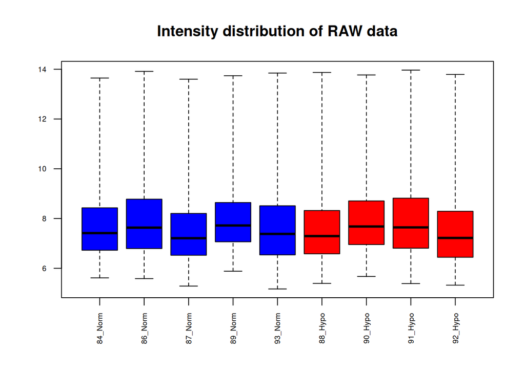

```r
# Boxplot RAW data
boxplot(rawData, which = "all", las = 2, main = "Intensity distribution of RAW data",
    cex.axis = 0.6, col = sampleColor, names = sampleNames)
```

```r
# Boxplot GDS Eset boxplot(gdsEset, which='all',las=2, main='Intensity
# distribution of GDS Eset', cex.axis=0.6, col=sampleColor, names=sampleNames)
```

#### 2.3.1.2 Agrupació Jeràrquica

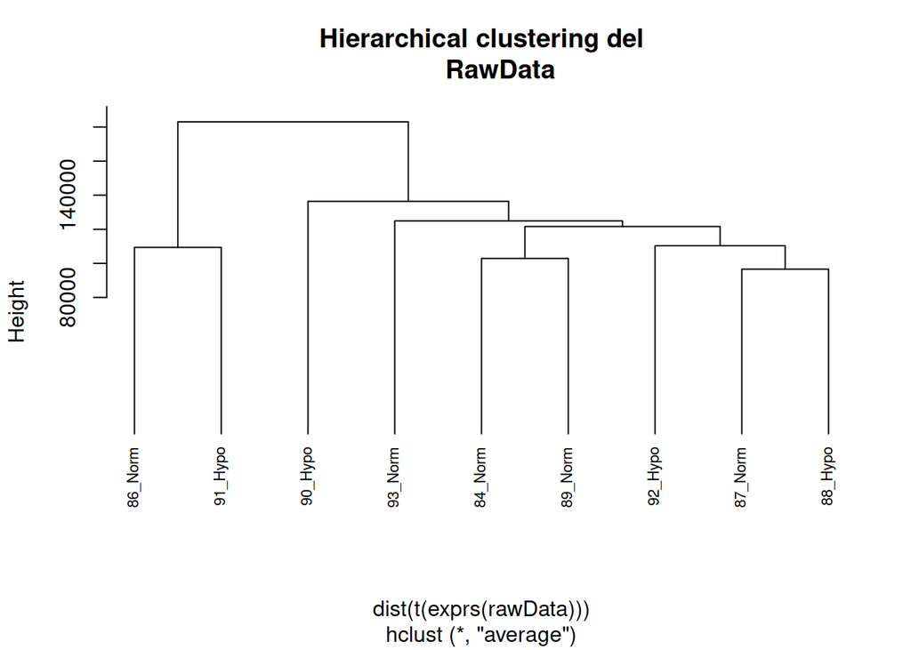

```r
# Hierarquical Clustering RAW data
clust.euclid.average <- hclust(dist(t(exprs(rawData))), method = "average")
plot(clust.euclid.average, labels = sampleNames, main = "Hierarchical clustering del
     RawData",
    cex = 0.7, hang = -1)
```

```r
# Hierarquical Clustering GDS Eset clust.euclid.average <-
# hclust(dist(t(exprs(gdsEset))),method='average') plot(clust.euclid.average,
# labels=sampleNames, main='Hierarchical clustering de GDS data', cex=0.7,
# hang=-1)
```

#### 2.3.1.3 Anàlisi de Components Principals (PCA)

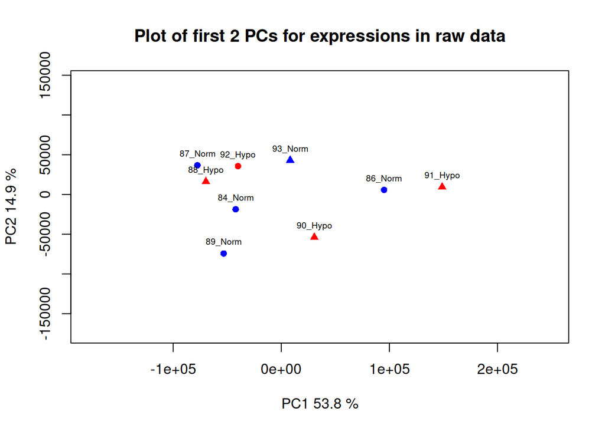

```r
# Anàlisis de Components Principals Definició de la funció
plotPCA <- function(X, labels = NULL, colors = NULL, dataDesc = "", scale = FALSE,
    formapunts = NULL, myCex = 0.8, ...) {
    pcX <- prcomp(t(X), scale = scale)  # o prcomp(t(X))
    loads <- round(pcX$sdev^2/sum(pcX$sdev^2) * 100, 1)
    xlab <- c(paste("PC1", loads[1], "%"))
    ylab <- c(paste("PC2", loads[2], "%"))
    if (is.null(colors))
        colors = 1
    plot(pcX$x[, 1:2], xlab = xlab, ylab = ylab, col = colors, pch = formapunts,
        xlim = c(min(pcX$x[, 1]) - 1e+05, max(pcX$x[, 1]) + 1e+05), ylim = c(min(pcX$x[,
            2]) - 1e+05, max(pcX$x[, 2]) + 1e+05))
    text(pcX$x[, 1], pcX$x[, 2], labels, pos = 3, cex = myCex)
    title(paste("Plot of first 2 PCs for expressions in", dataDesc, sep = " "), cex = 0.8)
}

# Raw data
plotPCA(exprs(rawData), labels = sampleNames, dataDesc = "raw data", colors = sampleColor,
    formapunts = c(rep(16, 4), rep(17, 4)), myCex = 0.6)
```

```r
# GDS Eset plotPCA(exprs(gdsEset), labels=sampleNames, dataDesc='GDS Eset',
# colors=sampleColor, formapunts=c(rep(16,4),rep(17,4)), myCex=0.6)
```

Guardem els anàlisi de qualitat en un arxiu PDF en el directori *results*

```r
# Ho gravem a un arxiu pdf al directori 'results'
pdf(file.path(resultsDir, "QCPlots_Raw.pdf"))
boxplot(rawData, which = "all", las = 2, main = "Intensity distribution of RAW data",
    cex.axis = 0.6, col = sampleColor, names = sampleNames)
plot(clust.euclid.average, labels = sampleNames, main = "Hierarchical clustering of samples of RawData",
    cex = 0.7, hang = -1)
plotPCA(exprs(rawData), labels = sampleNames, dataDesc = "raw data", colors = sampleColor,
    formapunts = c(rep(16, 4), rep(17, 4)), myCex = 0.6)
# Tanquem l'arxiu
dev.off()
```

### 2.3.2 Amb el paquet `arrayQualityMetrics`

Creem el directori *QC_RawData* on tindrem els resultats de l’anàlisis de qualitat fet per “arrayQualityMetrics” El control de qualitat amb *arrayQualityMetrics* consumeix cert temps pel que podem optar per executar-ho, o no fer-ho, usant una variable de tipus lògic.

```r
# Carreguem la llibreria 'arrayQualityMetrics'
require(arrayQualityMetrics)

# Evitem tornar-lo a executar cada vegada que s'executa l'script.
rerun <- FALSE
if (rerun) {
    # Raw Data
    arrayQualityMetrics(rawData, reporttitle = "QC_RawData", force = TRUE)
    # GDS Eset arrayQualityMetrics(gdsEset, reporttitle='QC_GDSEset',
    # force=TRUE)
}
```

## 2.4 Normalització

Fem servir el mètode RMA per normalitzar les dades Raw Data.

```r
# Normalitzem les dades Raw Data
myEset <- rma(rawData)
```

```
Background correcting
Normalizing
Calculating Expression
```

```r
write.exprs(myEset, file.path(resultsDir, "NormData.txt"))
myEset
```

```
ExpressionSet (storageMode: lockedEnvironment)
assayData: 15923 features, 9 samples
  element names: exprs
protocolData
  rowNames: 1 2 ... 9 (9 total)
  varLabels: exprs dates
  varMetadata: labelDescription channel
phenoData
  rowNames: 1 2 ... 9 (9 total)
  varLabels: fileName groups ShortName Colors
  varMetadata: labelDescription channel
featureData: none
experimentData: use 'experimentData(object)'
Annotation: pd.rae230a
```

Cal recordad que les dades descarregades amb GDS ja estan normalitzades.

## 2.5 Filtratge

Procedim a fer el filtratge amb la base de dades corresponent.

```r
require(genefilter)
# Farem servir la base de dades rae230a.db que és la que correspon a la
# plataforma GPL0341 d'Affymetrix (microarray)
annotation(myEset) <- "rae230a.db"
eset_filtered <- nsFilter(myEset, var.func = IQR, var.cutoff = 0.75, var.filter = TRUE,
    require.entrez = TRUE, filterByQuantile = TRUE)
# Nombre de gens filtrats (esborrats)
print(eset_filtered)
```

```
$eset
ExpressionSet (storageMode: lockedEnvironment)
assayData: 2690 features, 9 samples
  element names: exprs
protocolData
  rowNames: 1 2 ... 9 (9 total)
  varLabels: exprs dates
  varMetadata: labelDescription channel
phenoData
  rowNames: 1 2 ... 9 (9 total)
  varLabels: fileName groups ShortName Colors
  varMetadata: labelDescription channel
featureData: none
experimentData: use 'experimentData(object)'
Annotation: rae230a.db

$filter.log
$filter.log$numDupsRemoved
[1] 2537

$filter.log$numLowVar
[1] 8070

$filter.log$numRemoved.ENTREZID
[1] 2620

$filter.log$feature.exclude
[1] 6
```

```r
# Nombre de Gens que resten
print(eset_filtered$eset)
```

```
ExpressionSet (storageMode: lockedEnvironment)
assayData: 2690 features, 9 samples
  element names: exprs
protocolData
  rowNames: 1 2 ... 9 (9 total)
  varLabels: exprs dates
  varMetadata: labelDescription channel
phenoData
  rowNames: 1 2 ... 9 (9 total)
  varLabels: fileName groups ShortName Colors
  varMetadata: labelDescription channel
featureData: none
experimentData: use 'experimentData(object)'
Annotation: rae230a.db
```

Extraiem la matriu de dades filtrades que farem servir per continuar l’estudi.

```r
filteredEset <- eset_filtered$eset
filteredData <- exprs(filteredEset)
# Assignem el nom de les columnes els que hem definit a l'arxiu 'targets.csv'
colnames(filteredData) <- pData(filteredEset)$ShortName
# Visualitzem les primeres files
head(filteredData)
```

```
            84_Norm  86_Norm  87_Norm  89_Norm  93_Norm  88_Hypo  90_Hypo
1388383_at 8.322271 8.570291 8.322271 8.018906 8.647421 8.322271 8.167855
1373191_at 7.529336 7.675628 7.791007 7.867028 7.427315 7.759119 8.009510
1393669_at 5.474679 5.045734 5.066095 5.123502 4.911754 4.844921 5.441030
1372850_at 6.834757 7.131584 6.724878 6.492835 7.241871 7.010489 6.676976
1373964_at 6.844125 7.371164 7.320041 7.165110 7.316484 6.957853 6.921627
1390465_at 8.059365 7.558511 7.809494 7.809494 7.493047 7.867611 7.955898
            91_Hypo  92_Hypo
1388383_at 8.610859 8.322271
1373191_at 7.910771 8.058584
1393669_at 4.299795 4.627790
1372850_at 7.172263 6.834757
1373964_at 7.282614 7.187036
1390465_at 7.522304 7.912767
```

## 2.6 Selecció de gens

Construïm una matriu de disseny i una de contrast per l’anàlisis amb un model lineal. Farem servir el paquet *limma*.

**Matriu de disseny**

```r
require(limma)
treat <- pData(filteredEset)$groups
lev <- factor(treat, levels = unique(treat))
design <- model.matrix(~0 + lev)
colnames(design) <- levels(lev)
rownames(design) <- sampleNames
print(design)
```

```
        Control Hypotesion
84_Norm       1          0
86_Norm       1          0
87_Norm       1          0
89_Norm       1          0
93_Norm       1          0
88_Hypo       0          1
90_Hypo       0          1
91_Hypo       0          1
92_Hypo       0          1
attr(,"assign")
[1] 1 1
attr(,"contrasts")
attr(,"contrasts")$lev
[1] "contr.treatment"
```

**Matriu de contrast**

```r
# COMPARISON
cont.matrix1 <- makeContrasts(Hypotension.vs.Control = Hypotesion - Control, levels = design)
comparisonName <- "Efecte de la hipotensió induida"
print(cont.matrix1)
```

```
            Contrasts
Levels       Hypotension.vs.Control
  Control                        -1
  Hypotesion                      1
```

Estimació del model lineal

```r
# Estimació del model (F)
fit1 <- lmFit(filteredData, design)
fit.main1 <- contrasts.fit(fit1, cont.matrix1)
fit.main1 <- eBayes(fit.main1)
```

El resultat de l’anàlisi es troba a l’objecte `lmfit` i es pot extreure amb la instrucció *topTable*.

La instrucció `topTable` pot aplicar un filtre automàtic. En el nostra cas ens quedarem únicament els gens amb un “log-fold-change” major que 0 i un p-valor ajustat inferior a 0.05.

```r
# Fem servir l'instrucció 'topTable'
topTab <- topTable(fit.main1, number = nrow(fit.main1), coef = "Hypotension.vs.Control",
    adjust = "fdr", lfc = 0, p.value = 0.05)
# Veiem la seva dimensió
dim(topTab)
```

```
[1] 9 6
```

```r
# Observem els 10 primers resultats
head(topTab, n = 10)
```

```
                  logFC  AveExpr         t      P.Value  adj.P.Val        B
1370080_at    1.1974863 6.754096  5.310736 5.237648e-06 0.01408927 3.860589
1371754_at    1.1285814 7.605038  4.783239 2.694802e-05 0.02510877 2.424056
1370384_a_at -1.1165931 8.525278 -4.770784 2.800234e-05 0.02510877 2.390354
1368160_at    0.9749834 9.114729  4.653756 4.012558e-05 0.02653925 2.074408
1374699_at    1.2880989 6.025918  4.576299 5.086437e-05 0.02653925 1.866088
1369973_at    0.8802248 8.790700  4.480706 6.808066e-05 0.02653925 1.609988
1388901_at    0.9777805 8.135041  4.476005 6.906124e-05 0.02653925 1.597426
1370019_at    0.8809067 8.926622  4.332960 1.065382e-04 0.03582347 1.216651
1368778_at   -1.2137563 7.708883 -4.261152 1.322662e-04 0.03953289 1.026706
```

# 3 Resultats

## 3.1 Anotació dels resultats

Obtenim els identificadors ENTREZ, SYMBOL i GENENAME corresponents als probesets (identificats amb els id de la companyia que va produir el microarray) que apareixen a la taula de resultats.

En el nostre cas la companyia és *Affymetrix* i segons les seves expecificacions per els microarrays que s’han fet servir *(Platform GPL0341)* la base de dades que hem de fer servir és `rae230a.db`.

```r
require(rae230a.db)
# Veiem quins tipus d'identificadors
keytypes(rae230a.db)
```

```
 [1] "ACCNUM"       "ALIAS"        "ENSEMBL"      "ENSEMBLPROT"  "ENSEMBLTRANS"
 [6] "ENTREZID"     "ENZYME"       "EVIDENCE"     "EVIDENCEALL"  "GENENAME"
[11] "GENETYPE"     "GO"           "GOALL"        "IPI"          "ONTOLOGY"
[16] "ONTOLOGYALL"  "PATH"         "PFAM"         "PMID"         "PROBEID"
[21] "PROSITE"      "REFSEQ"       "SYMBOL"       "UNIPROT"
```

```r
# Guardem les anotacions
anotacions <- AnnotationDbi::select(rae230a.db, keys = rownames(filteredData), columns = c("ENTREZID",
    "SYMBOL", "GENENAME"))
```

Afegim les columnes d’anotacions a la topTable. Utilitzem funcions del paquet `dplyr` i “pipes” (%>%) per concatenar les instruccions. La columna “GENENAME” la afegim al final de la taula per a una lectura més còmoda.

```r
require(dplyr)
# Afegim la columna 'GENENAME'
topTabAnotada <- topTab %>%
    mutate(PROBEID = rownames(topTab)) %>%
    left_join(anotacions) %>%
    arrange(P.Value) %>%
    select(7, 8, 9, 1:6, 10)
# Visualitzem els 10 primers resultatss
head(topTabAnotada, n = 10)
```

```
       PROBEID ENTREZID   SYMBOL      logFC  AveExpr         t      P.Value
1   1370080_at    24451    Hmox1  1.1974863 6.754096  5.310736 5.237648e-06
2   1371754_at   246771 Slc25a25  1.1285814 7.605038  4.783239 2.694802e-05
3 1370384_a_at    24684     Prlr -1.1165931 8.525278 -4.770784 2.800234e-05
4   1368160_at    25685   Igfbp1  0.9749834 9.114729  4.653756 4.012558e-05
5   1374699_at   313969   Lratd1  1.2880989 6.025918  4.576299 5.086437e-05
6   1369973_at   497811      Xdh  0.8802248 8.790700  4.480706 6.808066e-05
7   1388901_at   361810    Fkbp5  0.9777805 8.135041  4.476005 6.906124e-05
   adj.P.Val        B                                     GENENAME
1 0.01408927 3.860589                             heme oxygenase 1
2 0.02510877 2.424056           solute carrier family 25 member 25
3 0.02510877 2.390354                           prolactin receptor
4 0.02653925 2.074408 insulin-like growth factor binding protein 1
5 0.02653925 1.866088                     LRAT domain containing 1
6 0.02653925 1.609988                       xanthine dehydrogenase
7 0.02653925 1.597426                      FKBP prolyl isomerase 5
 [ reached 'max' / getOption("max.print") -- omitted 2 rows ]
```

Escribin el resultat en un arxiu de text o a un arxiu html.

```r
write.csv2(topTabAnotada, file = file.path(resultsDir, "Gens_seleccionats.csv"))
print(xtable(topTab, align = "lllllll"), type = "html", html.table.attributes = "",
    file = file.path(resultsDir, "Gens_seleccionats.html"))
```

## 3.2 Visualització de resultats (1): Volcano Plot

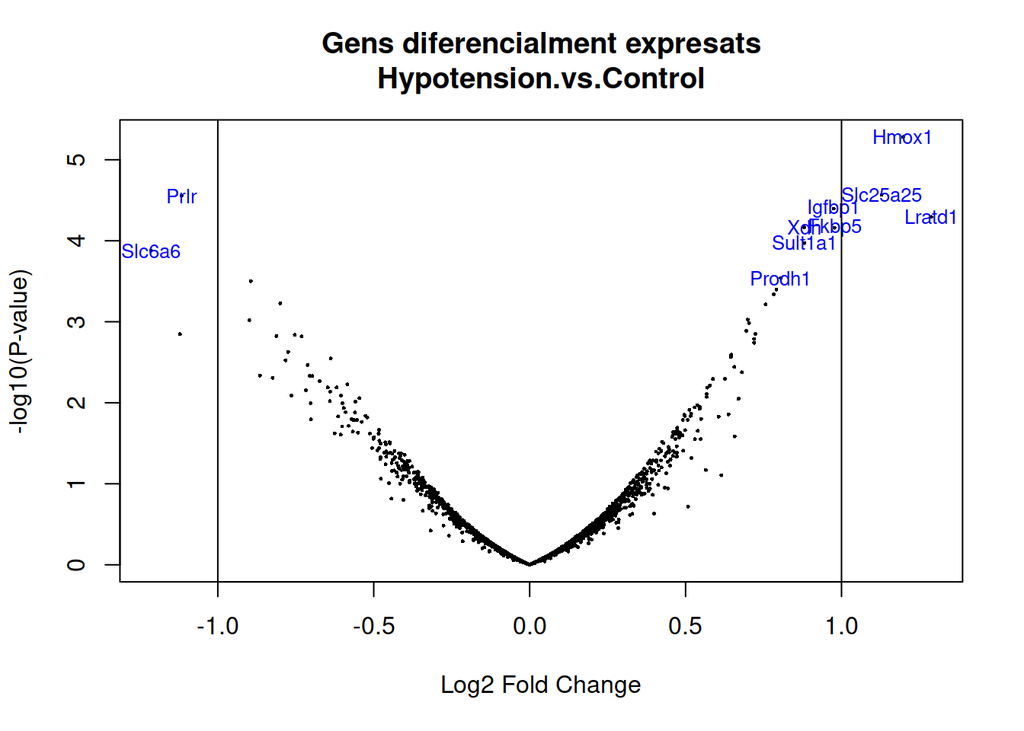

```r
# Anomenem amb SYMBOL els gens del model. Fem servir la base de dades
# d'anotacions rae230a.db
genenames <- AnnotationDbi::select(rae230a.db, rownames(fit.main1), c("SYMBOL"))$SYMBOL
# Dibuixem el volcano plot i ens dona el nom dels 10 més diferencialment
# expressats
volcanoplot(fit.main1, highlight = 10, names = genenames, main = paste("Gens diferencialment expresats",
    colnames(cont.matrix1), sep = "\n"))
abline(v = c(-1, 1))
```

```r
# El guardem a un pdf
pdf(file.path(resultsDir, "VolcanoPlot.pdf"))
# Dibuixem el volcano plot i ens dona el nom dels 10 més diferencialment
# expressats
volcanoplot(fit.main1, highlight = 10, names = genenames, main = paste("Gens diferencialment expresats",
    colnames(cont.matrix1), sep = "\n"))
abline(v = c(-1, 1))
dev.off()
```

## 3.3 Visualizació de resultats (2): Heatmaps

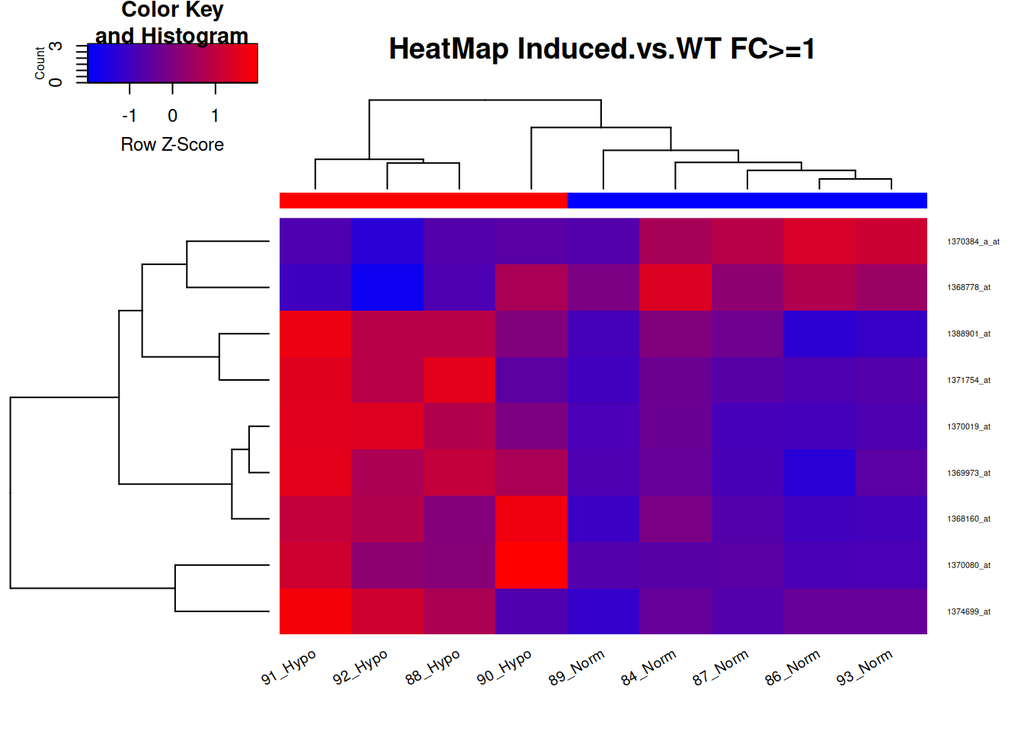

```r
selectedRows <- rownames(filteredData) %in% rownames(topTab)
selectedData <- filteredData[selectedRows, ]

# Heatmap Plot
my_palette <- colorRampPalette(c("blue", "red"))(n = 299)
library(gplots)
heatmap.2(selectedData, Rowv = TRUE, Colv = TRUE, main = "HeatMap Induced.vs.WT FC>=1",
    scale = "row", col = my_palette, sepcolor = "white", sepwidth = c(0.05, 0.05),
    cexRow = 0.5, cexCol = 0.9, key = TRUE, keysize = 1.5, density.info = "histogram",
    ColSideColors = c(rep("blue", 5), rep("red", 4)), tracecol = NULL, srtCol = 30)
```

```r
pdf(file.path(resultsDir, "Heatmap.pdf"))

# El guardem a un pdf
heatmap.2(selectedData, Rowv = TRUE, Colv = TRUE, main = "HeatMap Induced.vs.WT FC>=1",
    scale = "row", col = my_palette, sepcolor = "white", sepwidth = c(0.05, 0.05),
    cexRow = 0.5, cexCol = 0.9, key = TRUE, keysize = 1.5, density.info = "histogram",
    ColSideColors = c(rep("blue", 5), rep("red", 4)), tracecol = NULL, srtCol = 30)
dev.off()
```

## 3.4 Anàlisi de significació biològica

A títol il·lustratiu farem una anàlisi d’enriquiment (“Over-Representation Analysis”) a partir de la llista de gens seleccionats com a diferencialment expressats.

Per a l’anàlisi necessitem dues col·leccions de gens.

```r
require(rae230a.db)
# Per a l'anàlisi necessitem dues col·leccions de gens
probesUniverse <- rownames(filteredData)
entrezUniverse <- AnnotationDbi::select(rae230a.db, probesUniverse, "ENTREZID")$ENTREZID

topProbes <- rownames(selectedData)
entrezTop <- AnnotationDbi::select(rae230a.db, topProbes, "ENTREZID")$ENTREZID

# Eliminem posibles duplicats

topGenes <- entrezTop[!duplicated(entrezTop)]
entrezUniverse <- entrezUniverse[!duplicated(entrezUniverse)]
```

Es poden utilitzar molts paquets per fer una anàlisi d’enriquiment genètic.

En el nostre cas farem servir dos:  
-**GOstats** que ens permet fer una anàlisi d’enriquiment genètic.  
-**clusterProfiler** que ens permet fer una anàlisi d’enriquiment de conjunts de gens (Gene Set Enrichment Analysis - GSEA).

### 3.4.1 GOstats

Per fer servir fem farem servir “GOstats” necessitem crear un tipus especial d’objecte anomenat “Hiperparàmetre” que pot ser de tres classes.

Nosaltres farem servir la classes `GOHyperGParams` per fer una anàlisi basada en la Gene Ontology.

```r
require(GOstats)

# This parameter has an 'ontology' argument. It may be 'BP', 'MF' or 'CC' Other
# arguments are taken by default. Check the help for more information.

GOparams = new("GOHyperGParams", geneIds = topGenes, universeGeneIds = entrezUniverse,
    annotation = "rae230a.db", ontology = "BP", pvalueCutoff = 0.01)
```

Fem anar l’anàlisis

```r
# Fem l'anàlisis
GOhyper = hyperGTest(GOparams)
```

Extraiem resultats del summary.

```r
head(summary(GOhyper), n = 10)
```

```
       GOBPID      Pvalue OddsRatio    ExpCount Count Size
1  GO:0007595 0.003528376  29.59524 0.092894006     2   26
2  GO:0001762 0.003572846       Inf 0.003572846     1    1
3  GO:0006148 0.003572846       Inf 0.003572846     1    1
4  GO:0006149 0.003572846       Inf 0.003572846     1    1
5  GO:0006154 0.003572846       Inf 0.003572846     1    1
6  GO:0006157 0.003572846       Inf 0.003572846     1    1
7  GO:0006196 0.003572846       Inf 0.003572846     1    1
8  GO:0006204 0.003572846       Inf 0.003572846     1    1
9  GO:0006788 0.003572846       Inf 0.003572846     1    1
10 GO:0009114 0.003572846       Inf 0.003572846     1    1
                               Term
1                         lactation
2            beta-alanine transport
3         inosine catabolic process
4    deoxyinosine catabolic process
5       adenosine catabolic process
6  deoxyadenosine catabolic process
7             AMP catabolic process
8             IMP catabolic process
9                    heme oxidation
10   hypoxanthine catabolic process
```

```r
dim(summary(GOhyper))
```

```
[1] 66  7
```

Guardem els resultats en un informe html.

```r
# Creem un informe html amb els resultats
GOfilename = file.path(resultsDir, "GOResults.html")
htmlReport(GOhyper, file = GOfilename, summary.args = list(htmlLinks = TRUE))
```

### 3.4.2 GESEA amb clusterProfiler

Gene Set Enrichment Analysis(GESEA) amb el paquet clusterProfiler

Si, en comptes de confiar en les llistes de gens, decidim utilitzar tots els gens de la matriu i confrontar-los amb conjunts seleccionats de gens, podem utilitzar l’enfocament de l’anàlisi d’enriquiment de conjunts de gens.

```r
entrezIDs <- AnnotationDbi::select(rae230a.db, rownames(topTab), c("ENTREZID"))
topTab2 <- cbind(PROBEID = rownames(topTab), topTab)
geneList <- merge(topTab2, entrezIDs, by = "PROBEID")

# ordena per logFC absolut per eliminar els duplicats amb el logFC absolut més
# petit
geneList <- geneList[order(abs(geneList$logFC), decreasing = T), ]
geneList <- geneList[!duplicated(geneList$ENTREZ), ]
# tornar a ordenar basat en logFC per estar preparat per a GSEA
geneList <- geneList[order(geneList$logFC, decreasing = T), ]
genesVector <- geneList$logFC
names(genesVector) <- geneList$ENTREZ
# Llavor per reproduir resultats random
set.seed(123)

require(clusterProfiler)
gseResulti <- gseKEGG(geneList = genesVector, organism = "rno", keyType = "kegg",
    exponent = 1, minGSSize = 10, maxGSSize = 500, pvalueCutoff = 0.01, pAdjustMethod = "BH",
    verbose = TRUE, use_internal_data = FALSE, seed = TRUE, eps = 0, by = "fgsea")
```

Donat que no hem obtingut cap resultat la següent part de codi que ens donaria de forma esquemàtica els resultats, no l’executem

```r
require(kableExtra)
gsea.result <- setReadable(gseResulti, OrgDb = rae230a.db, keyType = "ENTREZID")
gsea.result.df <- as.data.frame(gsea.result)
print(kable(gsea.result.df[, c("Description", "setSize", "NES", "p.adjust")]) %>%
    scroll_box(height = "500px"))
```

```r
require(ggplot2)
# for (i in 1:length(files)){ cat('\nComparison: ', namesC[i],'\n')
cat("DOTPLOT\n")
# if(nrow(keggResultsList[[i]]) > 0){
if (nrow(gseResulti) > 0) {
    p <- dotplot(gseResulti, showCategory = 20, font.size = 15, title = paste("Enriched Pathways\n",
        comparisonName, split = ".sign") + facet_grid(. ~ .sign))
    plot(p)
    cat("\nENRICHMENT MAP\n")
    em <- emapplot(gseResulti)
    plot(em)
    # guardem en pdf
    pdf(file = paste0("KEGGplots.", comparisonName, ".pdf"), width = 14, height = 14)
    print(p)
    print(em)
    dev.off()
} else {
    cat("\nNo enriched terms found\n")
}
```

# 4 Discusió

En l’anàlisi exploratori veiem que en el boxplot la distribució entre els grups abans de normalitzar és bastant homogènia.  
L’agrupació jeràrquica no ens ha estat de gran utilitat atès que no ens ha agrupat gaire bé els diferents conjunts de rates.  
Tampoc en l’Anàlisi de Components Principals veiem que ens separi de forma clara els dos grups d’estudi.  
Un cop normalitzades les dades hem fet un filtratge dels gens. Amb aquest hem extret la matriu de dades amb la qual hem construït la matriu de dades i de contrast. Amb aquestes hem fet l’estimació amb un model lineal.

Dins dels gens que hem retingut d’aquest model ens han aparegut 2 dels que tenen funcions reguladores en el sistema cardiovascular, *Igfbp1, Xdh* tal i com exposen en l’estudi els autors:

*«Sis gens coneguts funcionalment (Igfbp1, Xdh, Sult1a1, Mawbp, Por i Gstm1) i dues seqüències expressades (BI277460 i AI411345) es van regular significativament. Quatre d’aquests gens (Igfbp1, Xdh, Por i Gstm1) tenen funcions ben caracteritzades en el sistema cardiovascular.»*

Per últim hem fet un anàlisi d’enriquiment genètic, que tot i ser didàctic, els resultats han estat més aviat pobres.

# 5 Referències

(Timm H Westhoff 2005)

Timm H Westhoff, Markus Tölle, Stefanie Scheid. 2005. “A Physiogenomic Approach to Study the Regulation of Blood Pressure.” *Physiol Genomics*, no. 23: 46–53. https://doi.org/10.1152/physiolgenomics.00077.2005.